# MSI Instrument – Sentinel-2 MSI Technical Guide – Sentinel Online - Sentinel Online

[Sentinel Online](https://sentinels.copernicus.eu/web/sentinel/home)

## MSI Instrument – Sentinel-2 MSI Technical Guide – Sentinel Online

## MultiSpectral Instrument (MSI) Overview

The design of the Multispectral Instrument (MSI) on-board SENTINEL-2 has been driven by the requirement for large swath high geometrical and spectral performance of the measurements.

The MSI measures the Earth's reflected radiance in 13 spectral bands from VNIR to SWIR (Table 1). **NOTE:** The Bandwidth (nm) is measured at Full Width Half Maximum (FWHM).

Table 1: Spectral bands for the SENTINEL-2 sensors (S2A & S2B)

|  | **S2A** |  | **S2B** |  |  |
| --- | --- | --- | --- | --- | --- |
| **Band Number** | **Central wavelength (nm)** | **Bandwidth (nm)** | **Central wavelength (nm)** | **Bandwidth (nm)** | Spatial resolution (m) |
| **1** | 442.7 | 21 | 442.3 | 21 | 60 |
| **2** | 492.4 | 66 | 492.1 | 66 | 10 |
| **3** | 559.8 | 36 | 559.0 | 36 | 10 |
| **4** | 664.6 | 31 | 665.0 | 31 | 10 |
| **5** | 704.1 | 15 | 703.8 | 16 | 20 |
| **6** | 740.5 | 15 | 739.1 | 15 | 20 |
| **7** | 782.8 | 20 | 779.7 | 20 | 20 |
| **8** | 832.8 | 106 | 833.0 | 106 | 10 |
| **8a** | 864.7 | 21 | 864.0 | 22 | 20 |
| **9** | 945.1 | 20 | 943.2 | 21 | 60 |
| **10** | 1373.5 | 31 | 1376.9 | 30 | 60 |
| **11** | 1613.7 | 91 | 1610.4 | 94 | 20 |
| **12** | 2202.4 | 175 | 2185.7 | 185 | 20 |

Figure 1 (below) shows the S2A spectral response functions (SRF) and transmission due to vertical column Water Vapour (WV) absorption for subarctic winter atmosphere (light blue, lowest WV content) and tropical atmosphere (darker blue, highest WV content). WV transmission data comes from MODTRAN.

**Note:** To see more detail, open the image to see a larger version.

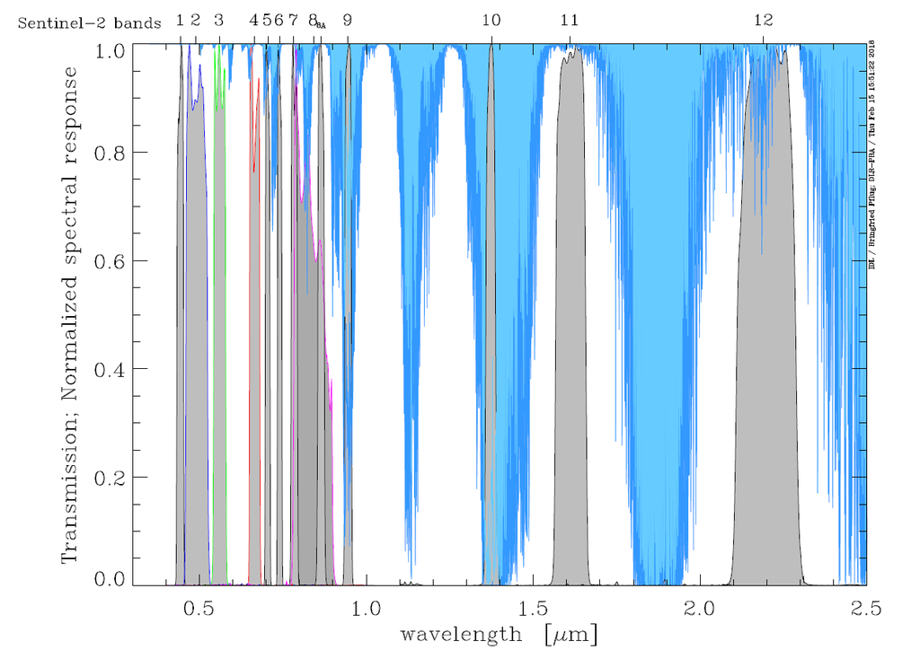

*Figure 1: SRF and transmission due to vertical column WV absorption*

### MSI instrument features

- A Three-Mirror Anastigmat (TMA) telescope with a pupil diameter equivalent to 150 mm, isostatically mounted on the platform to minimise thermo-elastic distortions. The optical design has been optimised to achieve state-of-the-art imaging quality across its very wide field of view. Its 290 km swath width is a larger swath than previous multi-spectral optical missions such as SPOT and LANDSAT. The telescope structure and the mirrors are made of silicon carbide, which provides a very high optical stability to mass ratio and minimises thermal deformation.
- Two focal planes based on:
  - monolithic Complementary Metal Oxide Semiconductor (CMOS) detectors for VNIR
  - mercury-cadmium-telluride (MCT) detectors hybridised on a CMOS read-out circuit for SWIR (the SWIR focal plane is passively thermo-controlled at temperatures below 195 K).
- A dichroic VNIR/SWIR beam splitter. Spectral separation in the various bands is provided by stripe filters mounted on top of the detectors.
- Two distinct arrays of 12 detectors mounted on each focal plane covering VNIR and SWIR channels respectively. The 12 detectors on each focal plane are in a staggered configuration to cover the entire field of view.
- A full-field and full-pupil on-board diffuser for radiometric calibration to guarantee high-quality radiometric performance.
- A shutter mechanism preventing the instrument from direct illumination by the sun. This mechanism is also used as a calibration device by collecting the sunlight after reflection by a diffuser.

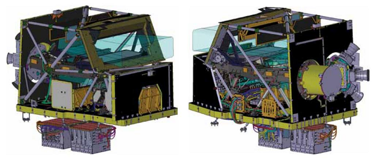

*Figure 2: The MultiSpectral Instrument (Airbus Defence and Space)*

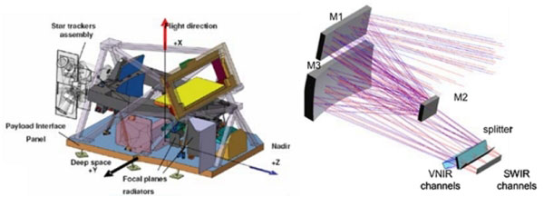

*Figure 3: MSI Internal Configuration*

The 12 detectors on each focal plane are mounted in a staggered formation (Figure 4) to cover the whole 20.6<sup>o</sup> instrument field of view, resulting in a compound swath width of 290 km on the ground track. As illustrated in the figure below, due to the staggered positioning of the detectors on the focal planes, a parallax angle between the two alternating odd and even clusters of detectors is induced in the measurements, resulting in a shift along track of approximately 46 km (maximum) inter-detector. Likewise, the hardware design of both the VNIR and SWIR detectors imposes a relative displacement of each spectral channel sensor within the detector resulting in an inter-band measurement parallax amounting to a maximum along track displacement of approximately 14 km.

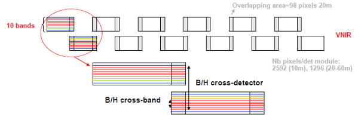

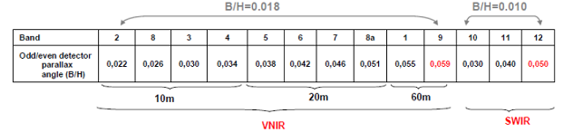

*Figure 4: Staggered Detector Configuration and Inter-Detector / Inter-Band Parallax Angles (parallax figures derived from MSI instrument documentation)*

Due to the particular geometrical layout of the focal plane, each spectral band of the MSI observes the ground surface at different times.

Table 2: The temporal offset (in seconds) between selected Bands

| **Inter-band Pair** | **Temporal offset between bands (seconds)** |
| --- | --- |
| B08 / B02 | 0.264 |
| B03 / B08 | 0.264 |
| B03 / B02 | 0.527 |
| B10 / B03 | 0.324 |
| B10 / B02 | 0.851 |
| B04 / B10 | 0.154 |
| B04 / B02 | 1.005 |
| B05 / B04 | 0.264 |
| B05 / B02 | 1.269 |
| B11 / B05 | 0.199 |
| B11 / B02 | 1.468 |
| B06 / B11 | 0.057 |
| B06 / B02 | 1.525 |
| B07 / B06 | 0.265 |
| B07 / B02 | 1.790 |
| B8a / B07 | 0.265 |
| B8a / B02 | 2.055 |
| B12 / B8a | 0.030 |
| B12 / B02 | 2.085 |
| B01 / B12 | 0.229 |
| B01 / B02 | 2.314 |
| B09 / B01 | 0.271 |
| B09 / B02 | 2.586 |

Technical Guides